# Project 2

```python
from datetime import date, timedelta
import os
import glob

import pandas as pd
import numpy as np
import matplotlib.pyplot as plt

%matplotlib inline

rcParams = {'figure.max_open_warning': 0,
            'figure.figsize': (15, 8),
            'axes.grid': True}

plt.rcParams.update(rcParams)
plt.style.use('bmh')

pd.options.display.max_rows = 50
```

# Loading Data

```python
# Reading CSV files and Loading the data
# filepath = r'c:\src\interview_project_data\*.csv'
filepath = r'/Users/kartiksaravana/Downloads/otppcmiaanalysttakehomeproject/*.csv'
csv_files = glob.glob(filepath)

data = {}

for csv_file in csv_files:
    print('Loading ', csv_file)
    data_key = csv_file.rsplit('/', 1)[-1].split('.')[0]
    df = pd.read_csv(csv_file)
    df.set_index('dates', inplace=True)
    df.index = pd.to_datetime(df.index)
    data[data_key] = df

print(data)
asset_prices = data['asset_prices']

# Firstly Grab the data by country
countries = ['US', 'CA']
data_labels = ['Unemployment', 'IndustrialProduction', 'GDP', 'HomeSales']

economic_data = {}

for country in countries:
    tmp_data = {}

    for label in data_labels:
        tmp_data[f'{label}'] = data[f'{country}_{label}']

    economic_data[f'{country}'] = tmp_data
```

[output not shown]

[output cut: 81 more lines]

[output not shown]

## Examining Data

```python
asset_prices
```

| dates | ES1 Index | PT1 Index | CADUSD Curncy | DXY Curncy |
| --- | --- | --- | --- | --- |
| 1980-01-01 | NaN | NaN | 0.8559 | 85.820 |
| 1980-01-02 | NaN | NaN | 0.8578 | 85.320 |
| 1980-01-03 | NaN | NaN | 0.8545 | 85.260 |
| 1980-01-04 | NaN | NaN | 0.8557 | 85.230 |
| 1980-01-07 | NaN | NaN | 0.8551 | 84.790 |
| ... | ... | ... | ... | ... |
| 2023-01-20 | 3988.50 | 1237.2 | 0.7474 | 102.012 |
| 2023-01-23 | 4036.50 | 1244.9 | 0.7481 | 102.138 |
| 2023-01-24 | 4032.75 | 1244.1 | 0.7480 | 101.918 |
| 2023-01-25 | 4032.00 | 1243.1 | 0.7467 | 101.641 |
| 2023-01-26 | 4061.25 | 1246.8 | 0.7500 | 101.863 |

11238 rows × 4 columns

```python
economic_data
```

```
{'US': {'Unemployment':             actual_value  expected_value  number_of_forecaster
  dates
  1997-02-07           5.4             5.3                   0.0
  1997-03-07           5.3             5.3                   0.0
  1997-04-04           5.2             5.2                   0.0
  1997-05-02           4.9             5.2                   0.0
  1997-06-06           4.8             5.0                   0.0
  ...                  ...             ...                   ...
  2022-05-06           3.6             3.5                  76.0
  2022-06-03           3.6             3.5                  69.0
  2022-07-08           3.6             3.6                  74.0
  2022-08-05           3.5             3.6                  71.0
  2022-09-02           3.7             3.5                  71.0

  [307 rows x 3 columns],
  'IndustrialProduction':             actual_value  expected_value  number_of_forecaster
  dates
  1997-02-14           0.0             0.2                   0.0
  1997-03-14           0.5             0.5                   0.0
  1997-04-16           0.9             0.6                   0.0
  1997-05-15           0.0             0.1                   0.0
  1997-06-17           0.4             0.3                   0.0
  ...                  ...             ...                   ...
  2022-04-15           0.9             0.4                  65.0
  2022-05-17           1.1             0.5                  65.0
  2022-06-17           0.2             0.4                  65.0
  2022-07-15          -0.2             0.1                  65.0
  2022-08-16           0.6             0.3                  60.0

  [307 rows x 3 columns],
  'GDP':             actual_value  expected_value  number_of_forecaster
  dates
  1997-04-30           5.6             4.2                   2.0
  1998-04-30           4.2             3.4                  19.0
  1998-07-31           1.4             0.4                  51.0
  1998-10-30           3.3             2.3                  67.0
  1999-01-29           5.6             4.4                  37.0
  ...                  ...             ...                   ...
  2021-07-29           6.5             8.4                  69.0
  2021-10-28           2.0             2.6                  70.0
```

[output cut: 65 more lines]

```
  'HomeSales':             actual_value  expected_value  number_of_forecaster
  dates
  2000-08-09       165.500          150.00                  16.0
  2000-09-11       146.000          159.50                   9.0
  2000-10-10       156.000          150.00                   8.0
  2000-11-08       164.800          153.50                  12.0
  2000-12-08       155.800          160.00                  13.0
  ...                  ...             ...                   ...
  2022-04-19       246.243          250.00                   9.0
  2022-05-16       267.330          245.69                  10.0
  2022-06-15       287.257          255.00                   7.0
  2022-07-18       273.841          274.00                   8.0
  2022-08-16       275.329          264.10                  11.0

  [264 rows x 3 columns]}}
```

## Economic Indicator

### First health/growth indicator - unemployment and home sales

Employment rate is directly proportional to productivity. Therefore, when Unemployment rates are trending down, it is a good indicator that the economy will grow. Consequently, increasing unemployment rates suggest a recession, which indicates that the economy will shrink.

Since many people, especially in the western world, rely on mortgages to buy homes, home sales may be seen as directly proportional to interest rates. Therefore, an increase in home sales is indicative of cheaper debt and a decrease in home sales is indicative of more expensive debt. Cheaper debt can be seen as an influx of capital to the economy, since business can borrow more aggressively and increase in growth. Therefore, when home sales are trending down, it is indicative of a shrinking stock market. Similarly, increasing home sales are indicative of a rising stock market.

### Second health/growth indicator - GDP and IP

GDP is the value of goods produced where value is based on purchase. Industrial production is the value of goods produced where value is based on cost to produce

If industrial production increases more than GDP, then it may be because currency might be weaker than foreign purchaser, or people have less money to spend on economy.

Therefore, GDP/production ratio can be used as an indicator for inflation.

GDP/production ratio increases can indicate decreasing inflation. GDP/production ratio increases can be due to things being cheaper to buy/produce, which results in more produced goods being purchased. Therefore, this is good for the stock market.

GDP/production ratio decreases can indicate increasing inflation. GDP/production ratio decreases can be due to things being more expensive to buy/produce, which leads to less produced goods being purchased. Therefore, this is bad for the stock market.

An increasing GDP/production ratio could also signify that the economy is moving from an industrial economy to a service economy. In my opinion, service economies are able to grow faster due to (less global competition and) increased margins. Therefore, when industrial production constitutes a smaller portion of a country's GDP, the economy (and stock market) has more room to grow.

Initially, I tried using this indicator for forex based on the following intuition.

- inflation starting: trade to foreign currency
  - at the start of inflation, this currency has high strength vs foreign currency
  - exchange rates favour buying foreign
- inflation ending: trade to home currency
  - at the end of inflation, this currency has low strength vs foreign currency
  - exchange rates favour selling foreign

There were two problems with this: Firstly, GDP/Production ratio may not be as strong an indicator of inflation as I thought. Secondly, my ratio signal (implemented in a future cell) was too restrictive to produce enough data to act as a signal for Canadian data (too many 0s).

Therefore, I decided to combine this GDP/IP change ratio with the HomeSales, Unemployment indicator.

### Building the stocks indicator

```python
### Building a partial indicator using unemployment
us_unemploy = economic_data['US']['Unemployment']['actual_value'].resample('M').sum()

us_unemploy_sma_20 = us_unemploy.rolling(10, min_periods=1).mean()
us_unemploy_sma_5 = us_unemploy.rolling(5, min_periods=1).mean()
us_unemploy_trending_down = (us_unemploy_sma_20-us_unemploy_sma_5)

### Building a partial indicator using unemployment
ca_unemploy = economic_data['CA']['Unemployment']['actual_value']

ca_unemploy_sma_20 = ca_unemploy.resample('M').sum().rolling(20, min_periods=1).mean()
ca_unemploy_sma_5 = us_unemploy.resample('M').sum().rolling(5, min_periods=1).mean()
ca_unemploy_trending_down = (ca_unemploy_sma_20-ca_unemploy_sma_5)
```

```python
### Building a partial indicator using home sales
us_home = economic_data['US']['HomeSales']['actual_value'].resample('M')

us_home_sma_20 = us_home.sum().rolling(10, min_periods=1).mean()
us_home_sma_5 = us_home.sum().rolling(5, min_periods=1).mean()
us_home_trending_up = (us_home_sma_5-us_home_sma_20).reindex_like(us_unemploy_trending_down).fillna(0)
us_home_trending_up
```

```
dates
1997-02-28    0.00
1997-03-31    0.00
1997-04-30    0.00
1997-05-31    0.00
1997-06-30    0.00
              ...
2022-05-31   -2.80
2022-06-30   -2.15
2022-07-31   -1.06
2022-08-31   -0.57
2022-09-30    0.00
Freq: M, Name: actual_value, Length: 308, dtype: float64
```

```python
### Building a partial indicator using home sales
ca_home = economic_data['CA']['HomeSales']['actual_value'].resample('M').sum()

ca_home_sma_20 = ca_home.rolling(20, min_periods=1).mean()
ca_home_sma_5 = ca_home.rolling(5, min_periods=1).mean()
ca_home_trending_up = (ca_home_sma_5-ca_home_sma_20).reindex_like(ca_unemploy_trending_down).fillna(0)
ca_home_trending_up
```

```
dates
1997-02-28     0.00000
1997-03-31     0.00000
1997-04-30     0.00000
1997-05-31     0.00000
1997-06-30     0.00000
                ...
2022-05-31   -11.33215
2022-06-30    -5.01580
2022-07-31     0.65330
2022-08-31     4.80310
2022-09-30     0.00000
Freq: M, Name: actual_value, Length: 308, dtype: float64
```

```python
us_indicator = us_home_trending_up + us_unemploy_trending_down
ca_indicator = ca_home_trending_up + ca_unemploy_trending_down
us_indicator
```

```
dates
1997-02-28    0.00
1997-03-31    0.00
1997-04-30    0.00
1997-05-31    0.00
1997-06-30    0.00
              ...
2022-05-31   -2.27
2022-06-30   -1.74
2022-07-31   -0.73
2022-08-31   -0.31
2022-09-30    0.15
Freq: M, Name: actual_value, Length: 308, dtype: float64
```

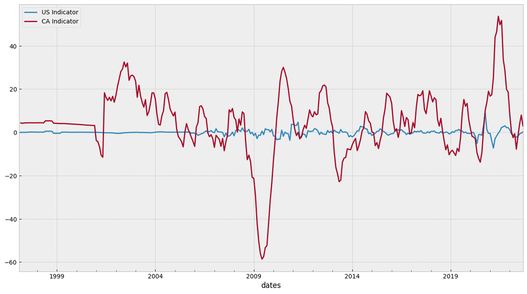

```python
us_indicator.plot(label='US Indicator')
ca_indicator.plot(label='CA Indicator')
plt.legend()
```

### Building second indicator using GDP/IP ratio

I calculate the forex indicator by calculating the ratio between the GDP changes and Industrial Production changes.

```python
# Get dataframe with GDP and IP
us_ip = economic_data['US']['IndustrialProduction']['actual_value']
us_gdp = economic_data['US']['GDP']['actual_value']
us_prod = pd.concat([us_gdp.diff(), us_ip.diff()], axis=1, keys=['GDP', 'IP'])
us_prod

ca_ip = economic_data['CA']['IndustrialProduction']['actual_value']
ca_gdp = economic_data['CA']['GDP']['actual_value']
ca_prod = pd.concat([ca_gdp.diff(), ca_ip.diff()], axis=1, keys=['GDP', 'IP'])
ca_prod
```

| dates | GDP | IP |
| --- | --- | --- |
| 1997-03-17 | NaN | NaN |
| 1997-04-16 | NaN | -1.6 |
| 1997-05-16 | NaN | -0.2 |
| 1997-06-27 | NaN | 0.1 |
| 1997-07-16 | NaN | -0.7 |
| ... | ... | ... |
| 2022-06-30 | -0.4 | NaN |
| 2022-07-14 | NaN | -3.7 |
| 2022-07-29 | -0.3 | NaN |
| 2022-08-15 | NaN | 1.2 |
| 2022-08-31 | 0.1 | NaN |

574 rows × 2 columns

```python
# Get the currency indicators by dividing GDP by IP
us_prod_indicator = us_prod.resample('M').sum()
is_negative = (us_prod_indicator < 0)
us_prod_indicator = (us_prod_indicator['GDP'] / us_prod_indicator['IP']).diff()
is_negative = is_negative['GDP'] | is_negative['IP']
us_prod_indicator[is_negative] = us_prod_indicator[is_negative] * -1

ca_prod_indicator = ca_prod.resample('M').sum()
is_negative = (ca_prod_indicator < 0)
ca_prod_indicator = (ca_prod_indicator['GDP'] / ca_prod_indicator['IP']).diff()
is_negative = is_negative['GDP'] | is_negative['IP']
ca_prod_indicator[is_negative] = ca_prod_indicator[is_negative] * -1
```

## Building first signal

```python
def basic_signal(ts):
    # ts is a vector
    signal = pd.DataFrame(np.zeros((len(ts.index), 1)),index=ts.index, columns=['signal'])
    signal[ts > 0] = 1
    signal[ts < 0] = -1

    return signal
```

```python
us_unemp_sgnl = basic_signal(us_unemploy_trending_down)
us_home_sgnl = basic_signal(us_home_trending_up)
us_home_sgnl.index = us_unemp_sgnl.index
us_sgnl = basic_signal(us_unemp_sgnl + us_home_sgnl)
us_home_sgnl
```

| dates | signal |
| --- | --- |
| 1997-02-28 | 0.0 |
| 1997-03-31 | 0.0 |
| 1997-04-30 | 0.0 |
| 1997-05-31 | 0.0 |
| 1997-06-30 | 0.0 |
| ... | ... |
| 2022-05-31 | -1.0 |
| 2022-06-30 | -1.0 |
| 2022-07-31 | -1.0 |
| 2022-08-31 | -1.0 |
| 2022-09-30 | 0.0 |

308 rows × 1 columns

```python
ca_unemp_sgnl = basic_signal(ca_unemploy_trending_down)
ca_home_sgnl = basic_signal(ca_home_trending_up)
ca_home_sgnl.index = ca_unemp_sgnl.index
ca_sgnl = basic_signal(ca_unemp_sgnl + ca_home_sgnl)
ca_home_sgnl
```

| dates | signal |
| --- | --- |
| 1997-02-28 | 0.0 |
| 1997-03-31 | 0.0 |
| 1997-04-30 | 0.0 |
| 1997-05-31 | 0.0 |
| 1997-06-30 | 0.0 |
| ... | ... |
| 2022-05-31 | -1.0 |
| 2022-06-30 | -1.0 |
| 2022-07-31 | 1.0 |
| 2022-08-31 | 1.0 |
| 2022-09-30 | 0.0 |

308 rows × 1 columns

### Building "improved" Signal

Since my GDP/IP indicator is a ratio, the signal instructs to buy foreign currency when GDP grows faster than IP and instructs to sell foreign currency when GDP shrinks faster than IP.

This ignores cases where GDP shrinks/grows slower than IP.

```python
def ratio_signal(ts):
    # ts is a vector
    signal = pd.DataFrame(np.zeros((len(ts.index), 1)),index=ts.index, columns=['signal'])
    signal[(ts > 1)] = 1
    signal[(ts < -1)] = -1

    return signal
```

```python
us_prod_sgnl = basic_signal(ratio_signal(us_prod_indicator) + us_sgnl)
ca_prod_sgnl = basic_signal(ratio_signal(ca_prod_indicator) + ca_sgnl)
```

## Testing P/L of signal

```python
# In this case, we are postulating that when unemployment drops and home sales increase,
# the stock market will increase as well
ca_assets = ['PT1 Index']
us_assets = ['ES1 Index']

ca_prod_assets = ['PT1 Index']
us_prod_assets = ['ES1 Index']
```

```python
def calculate_pnl(ret, pos):
    # function to calculate profit and loss
    # we trade at the end of the period, and take profit & loss on the market move next period on our position
    # that's why we are shifting positon vector by one
    return ret.multiply(pos.shift(), axis=0).dropna()
```

```python
# build the return series for each of the series
ca_returns = asset_prices[ca_assets].pct_change()
us_returns = asset_prices[us_assets].pct_change()

us_prod_returns = asset_prices[us_prod_assets].pct_change()
ca_prod_returns = asset_prices[ca_prod_assets].pct_change()

# Resample the Signal into daily signal
ca_daily_pos = ca_sgnl.resample('D').ffill()
us_daily_pos = us_sgnl.resample('D').ffill()

us_daily_pos_prod = us_prod_sgnl.resample('D').ffill()
ca_daily_pos_prod = ca_prod_sgnl.resample('D').ffill()
```

```python
us_pnl = calculate_pnl(us_returns, us_daily_pos['signal'])
ca_pnl = calculate_pnl(ca_returns, ca_daily_pos['signal'])
```

```python
us_prod_pnl = calculate_pnl(us_returns, us_daily_pos_prod['signal'])
ca_prod_pnl = calculate_pnl(ca_returns, ca_daily_pos_prod['signal'])
```

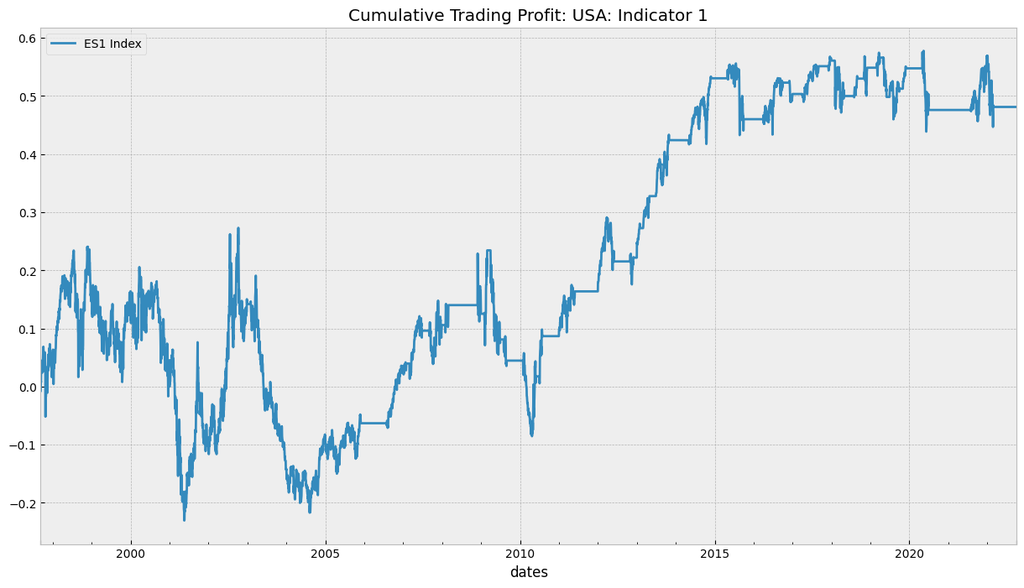

```python
us_pnl.cumsum().plot(title='Cumulative Trading Profit: USA: Indicator 1')
```

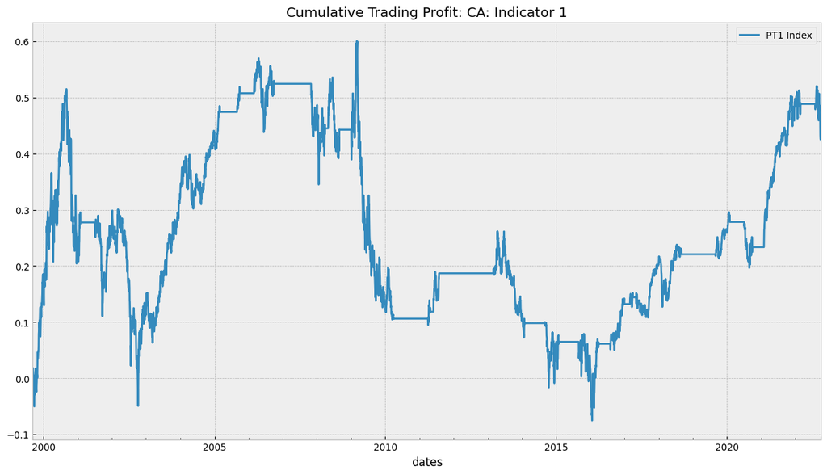

```python
ca_pnl.cumsum().plot(title='Cumulative Trading Profit: CA: Indicator 1')
```

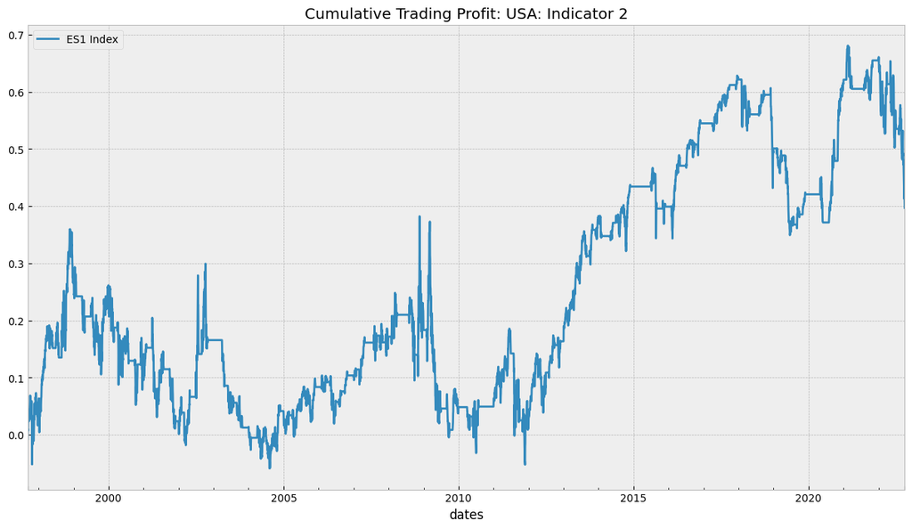

```python
us_prod_pnl.cumsum().plot(title='Cumulative Trading Profit: USA: Indicator 2')
```

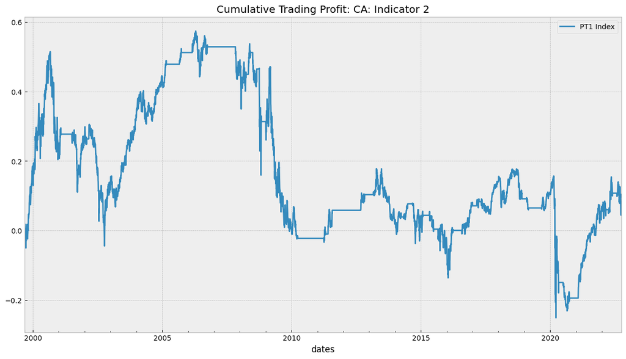

```python
ca_prod_pnl.cumsum().plot(title='Cumulative Trading Profit: CA: Indicator 2')
```

## Some thoughts on the performance of the trading signal

Using home sales and unemployment as the only indicator for stock market growth did not perform well in Canada. The simple GDP indicator given in the example outperformed this indicator.

Specific to Canada, the increased demand for homes and the resulting housing bubble may cause/have caused inflated house sales numbers even during fluctuations in interest rates. Therefore, this may not be a good indicator for cost of debt for companies in Canada. (My fund would've been wiped out in 2008 without even being involved in credit default swaps)

Firstly, I think that augmenting a better GDP indicator with my home sales and unemployment indicators would deliver better results. While unemployment does indicate recession, and home sales changes does indicate inflation and interest rate changes, the most important indicator for economic growth is growth in GDP. Therefore, it should've been the base for the indicator (with adjustments made using the other indicators).

Secondly, the indicators I combined are weighted improperly because I directly used the difference between the two SMAs directly, instead of calculating a percent value. Especially for Canada, this skewed the home-unemployment indicator to be mostly based on home sales. The ratio signal I used for GDP/IP (which was later added to the home-unemployment signal) was too restrictive in that it ignores values for the -1 < ratio < 1. A better signal function may have produced more non-zero data points in Canada.

If I were to further explore this investigation, I would take the following steps:

- Investigate if using .pct_change() for home sales numbers has an impact on the returns
- Do more research on the effects of GDP, industrial production, unemployment and home sales on debt cycles and inflation cycles (and vice versa)
- Combine the current trend indicators with a better GDP indicator
- Implement a new signal that can combine the indicators with weights:
  - GDP weighted the most
  - Unemployment weighted second
  - Home sales weighted least
- Investigate using EMA5 instead of SMA5 to further contrast trends, since EMA would weigh the months closer to current conditions. EMA5 would break past SMA10 in either direction than SMA5.
- Investigate using the difference between expected and actual values to calculate trends in GDP (and other indicators) by calculating a small-window moving average weighted by number of forecasters